# Assignment2Q2

Benjamin Moran

18 September 2016

## Question 2 Total: 13 marks

The table below is adapted from the text BDA. It consists of the numbers of fatal accidents and approximate numbers of passenger miles (in 100 millions) flown each year from 1976 to 1985.

|  | Fatal Accidents | Passenger Miles |
| --- | --- | --- |
| 1976 | 24 | 3863 |
| 1977 | 25 | 4300 |
| 1978 | 31 | 5027 |
| 1979 | 31 | 5481 |
| 1980 | 22 | 5814 |
| 1981 | 21 | 6033 |
| 1982 | 26 | 5877 |
| 1983 | 20 | 6223 |
| 1984 | 16 | 7433 |
| 1985 | 22 | 7107 |

1. Assume the numbers of fatal accidents are independently and identically distributed. Suggest an appropriate distribution to model the number of fatal accidents. [2 marks]

**Answer:** An appropriate model to use would be a Poisson model. We would have a parameter $\theta$ representing the *expected* number of accidents occuring in a year and data $y_{i}$ representing the *actual* number of accidents each year. So, $y_{i} \mid \theta \sim Pois(\theta)$. An appropriate distribution that we can use to model this would be a Gamma distribution:
$$y_{i} \mid \theta \sim Gamma(\alpha, \beta) = Gamma(n\bar{y_{i}}, n) = Gamma(238, 10)$$

2. Set a suitable prior distribution for the mean parameter in (a) and determine its posterior distribution based on the data in the table above. Plot this posterior density. [3 marks]

**Answer:** From the data we can see that there have been 238 fatal accidents in $n = 10$ years. If we assume a non-informative $Gamma(1,0)$ prior, then the posterior distribution for the mean parameter is
$$Gamma_{post}(\alpha, \beta) = Gamma(1 + n\bar{y_{i}}, 0 + n) = Gamma(239, 10)$$

```r
fatal.accidents <- c(24,25,31,31,22,21,26,20,16,22)
miles.flown <- c(3863,4300,5027,5481,5814,6033,5877,6223,7433,7107)
mu.y <- mean(fatal.accidents)

a0 <- 1; b0 <- 0; n <- 10

post.data1 <- rgamma(10000,a0 + n*mu.y, b0 + n)
```

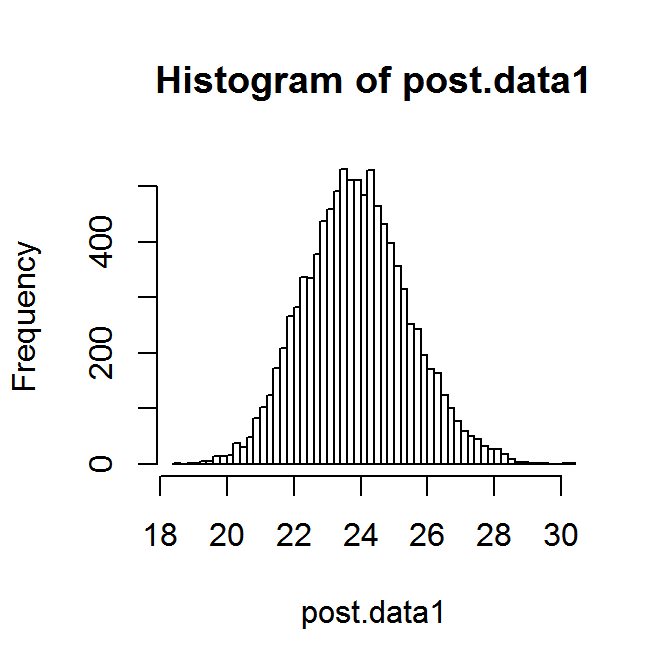

```r
hist(post.data1,50)
```

3. Find a point estimate and 95% interval for the average yearly number of fatal accidents. [2 marks]

**Answer:** We do this by going back to the Poisson model.

```r
theta <- rgamma(1000,n*mu.y)/(n)
theta.hat <- rpois(1000,theta)
quantile(theta.hat,c(0.025,0.975))
```

```
##  2.5% 97.5%
##    14    34
```

```r
mean(theta.hat)
```

```
## [1] 23.544
```

Here we can see an estimate of 23.544 for the mean, with a $95$% CI of 14, 34.

4. Part (a) has ignored the information about passenger miles. Perhaps a better model here would take account that each fatal accident count is proportional to the number of miles flown. Set up a model of accident counts that accounts for the number of miles flown. [2 marks]

**Answer:** Again, we have a Poisson model with an appropriate Gamma distribution. By accounting for the number of passenger miles flown ($x_{i}$), our model becomes $y_{i} \mid x_{i}, \theta \sim Pois(x_{i}\theta)$, which leads to a conjugate prior Gamma of:
$$y_{i} \mid \theta \sim Gamma(\alpha, \beta) = Gamma(n\bar{y_{i}}, n\bar{x_{i}}) = Gamma(238, 5715.8*10^{12})$$

5. Using this new model, set a prior distribution for the mean parameter and determine its posterior distribution. Plot this density and compare it with that in (b). [4 marks]

**Answer:** Again, assuming a non-informative conjugate prior of $Gamma(1,0)$, our posterior becomes:
$$y_{i} \mid \theta \sim Gamma_{post}(\alpha, \beta) = Gamma(1 + n\bar{y_{i}}, 0 + n\bar{x_{i}}) = Gamma(239, 5715.8*10^{12})$$

```r
mu.miles <- mean(miles.flown*10^(11))
mu.miles
```

```
## [1] 5.7158e+14
```

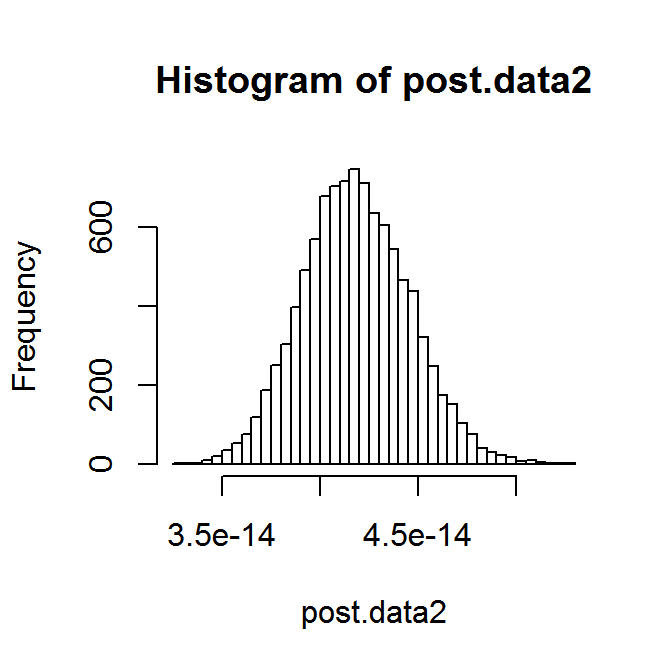

```r
a0 <- 1; b0 <- 0; n <- 10
post.data2 <- rgamma(10000,a0 + n*mu.y, b0 + n*mu.miles)
hist(post.data2,50)
```

```r
qgamma(0.025,a0 + n*mu.y, b0 + n*mu.miles)
```

```
## [1] 3.668037e-14
```

```r
qgamma(0.975,a0 + n*mu.y, b0 + n*mu.miles)
```

```
## [1] 4.727878e-14
```

```r
theta <- rgamma(1000,n*mu.y)/(mu.miles*n)
theta.hat <- rpois(1000,theta*mu.miles)
quantile(theta.hat,c(0.025,0.975))
```

```
##  2.5% 97.5%
##    15    35
```

```r
mean(theta.hat)
```

```
## [1] 24.154
```

Here we can see an estimate of 24.154 for the mean, with a $95$% CI of 15, 35. Note that these are virtually identical to the estimates arrived at by our first model. The similarities betwen the two outputs are made clearer when we plot their densities.

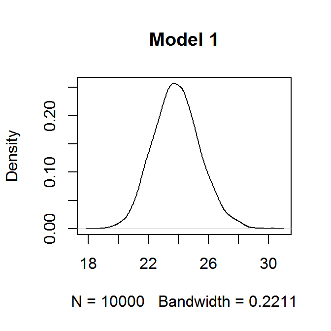

```r
plot(density(post.data1), main = "Model 1")
```

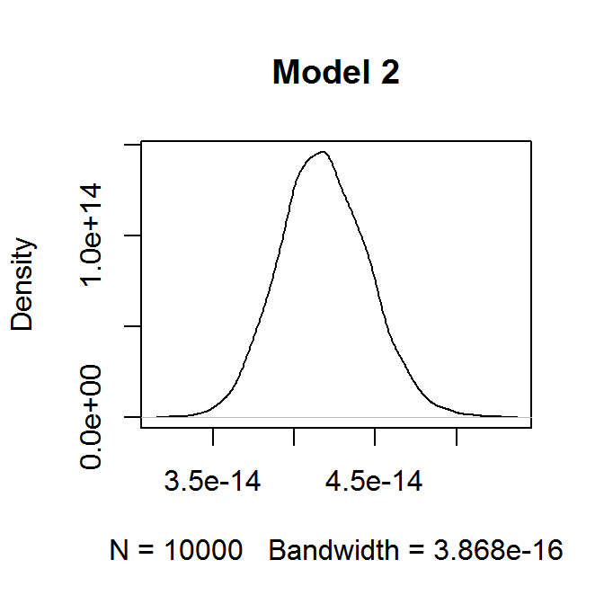

```r
plot(density(post.data2), main = "Model 2")
```

Both seem to be very similar. Along with the similarities in the estimates, we should conclude that the new model has not improved our ability to estimate the true parameters of the data.